# Pon un título a tu documento

# 4 4. Fichero SPSS *PsychBike.sav*

## 4.1 Importación del fichero

Podemos leer ficheros de IBM SPSS mediante la librería `haven`.

1. Leer el fichero con `read_sav`.

```r
#install.packages('haven')
library(haven)

filename <- "data/PsychBike.sav"
data_sec4 <- read_sav(filename)
```

2. Inspección de los datos

```r
str(data_sec4)
```

```
tibble [2,355 × 6] (S3: tbl_df/tbl/data.frame)
 $ vehicle           : dbl+lbl [1:2355] 1, 5, 2, 1, 4, 1, 2, 1, 4, 7, 2, 3, 1, 1, 1, 2, 1, 2, 1, 1, 1, 1, 1, 2, 1, 1, 7, 1, 6, 1, 2, 1, 1, 2, 1, 7, 1, 1, 3, 2, 2,...
   ..@ format.spss: chr "F11.0"
   ..@ labels     : Named num [1:7] 1 2 3 4 5 6 7
   .. ..- attr(*, "names")= chr [1:7] "car" "LGV" "SUV" "bus" ...
 $ Colour            : dbl+lbl [1:2355]  1,  2,  1, 99,  9,  3,  4,  2,  2, 99,  4,  4,  1,  1,  1,  4,  2,  4,  3,  4,  3,  2,  5,  4,  1,  6, 99,  2,  3,  1,  4...
   ..@ format.spss: chr "F11.0"
   ..@ labels     : Named num [1:8] 1 2 3 4 5 6 9 99
   .. ..- attr(*, "names")= chr [1:8] "blue" "red" "silver/grey" "white" ...
 $ hour              : 'hms' num [1:2355] 16:00:00 16:00:00 16:00:00 16:00:00 ...
  ..- attr(*, "units")= chr "secs"
  ..- attr(*, "format.spss")= chr "TIME11.2"
 $ helmet            : num [1:2355] 0 0 0 0 0 0 1 1 1 1 ...
  ..- attr(*, "format.spss")= chr "F11.0"
 $ Distance_from_kerb: num [1:2355] 0.5 0.5 0.5 0.5 0.5 0.5 1 1 1 1 ...
  ..- attr(*, "label")= chr "Distance from kerb"
  ..- attr(*, "format.spss")= chr "F11.1"
 $ Passing_distance  : num [1:2355] 1.864 0.748 1.567 1.39 1.294 ...
  ..- attr(*, "label")= chr "Passing distance"
  ..- attr(*, "format.spss")= chr "F11.3"
```

```r
head(data_sec4)
```

| vehicle | Colour | hour | helmet | Distance_from_kerb | Passing_distance |
| --- | --- | --- | --- | --- | --- |
| 1 | 1 | 16:00:00 | 0 | 0.5 | 1.864 |
| 5 | 2 | 16:00:00 | 0 | 0.5 | 0.748 |
| 2 | 1 | 16:00:00 | 0 | 0.5 | 1.567 |
| 1 | 99 | 16:00:00 | 0 | 0.5 | 1.390 |
| 4 | 9 | 16:00:00 | 0 | 0.5 | 1.294 |
| 1 | 3 | 16:00:00 | 0 | 0.5 | 1.259 |

```r
tail(data_sec4)
```

| vehicle | Colour | hour | helmet | Distance_from_kerb | Passing_distance |
| --- | --- | --- | --- | --- | --- |
| 2 | 9 | 10:00:00 | 1 | 1.25 | 1.104 |
| 1 | 3 | 10:00:00 | 1 | 1.25 | 1.010 |
| 1 | 2 | 10:00:00 | 1 | 1.25 | 0.922 |
| 5 | 4 | 10:00:00 | 1 | 1.25 | 0.564 |
| 1 | 1 | 10:00:00 | 1 | 1.25 | 0.650 |
| 1 | 6 | 10:00:00 | 1 | 1.25 | 0.781 |

```r
summary(data_sec4)
```

```
    vehicle          Colour            hour                     helmet       Distance_from_kerb Passing_distance
 Min.   :1.000   Min.   : 1.000   Min.   :07:00:00.000000   Min.   :0.0000   Min.   :0.2500     Min.   :0.144
 1st Qu.:1.000   1st Qu.: 1.000   1st Qu.:10:00:00.000000   1st Qu.:0.0000   1st Qu.:0.2500     1st Qu.:1.053
 Median :1.000   Median : 3.000   Median :12:00:00.000000   Median :0.0000   Median :0.5000     Median :1.279
 Mean   :1.634   Mean   : 3.556   Mean   :12:05:37.834395   Mean   :0.4879   Mean   :0.6702     Mean   :1.314
 3rd Qu.:2.000   3rd Qu.: 4.000   3rd Qu.:15:00:00.000000   3rd Qu.:1.0000   3rd Qu.:1.0000     3rd Qu.:1.540
 Max.   :7.000   Max.   :99.000   Max.   :17:00:00.000000   Max.   :1.0000   Max.   :1.2500     Max.   :3.537
```

# 5 5. Fichero data *iris.zip*

Visualiza la pagina web de los datos [Iris del repostorio de UCI Machine Learning](https://archive.ics.uci.edu/dataset/53/iris), copia el link de descarga y guarda el archivo zip en la carpeta data.

## 5.1 Descomprimir el fichero

1. Utiliza la funcion `unzip` para descoprimirlo en la carpeta data.

```r
URL <- 'https://archive.ics.uci.edu/static/public/53/iris.zip'
pathfile <- './data/iris.zip'
download.file(url=URL, destfile=pathfile)
savedir <- './data/iris'
if (!file.exists(savedir)) dir.create(savedir)
unzip(pathfile, exdir=savedir)
```

# 6 6. Fichero data *iris.data*

## 6.1 Importación del fichero

1. Utiliza la funcion `read_table` para importar los datos.

```r
savedir <- './data/iris/'
filename <- 'iris.data'
data_sec6 <- read.table(paste0(savedir,filename))
```

2. Cambia el nombre de las columnas por las que corresponda a la base datos (mirar la información en la página web).

```r
names(data_sec6) <- c('sepal_length', 'sepal_width', 'petal_width', 'petal_width', 'class')
data_sec6
```

| sepal_length | sepal_width | petal_width | petal_width | class |
| --- | --- | --- | --- | --- |
| 5.1 | 3.5 | 1.4 | 0.2 | Iris-setosa |
| 4.9 | 3.0 | 1.4 | 0.2 | Iris-setosa |
| 4.7 | 3.2 | 1.3 | 0.2 | Iris-setosa |
| 4.6 | 3.1 | 1.5 | 0.2 | Iris-setosa |
| 5.0 | 3.6 | 1.4 | 0.2 | Iris-setosa |
| 5.4 | 3.9 | 1.7 | 0.4 | Iris-setosa |
| 4.6 | 3.4 | 1.4 | 0.3 | Iris-setosa |
| 5.0 | 3.4 | 1.5 | 0.2 | Iris-setosa |
| 4.4 | 2.9 | 1.4 | 0.2 | Iris-setosa |
| 4.9 | 3.1 | 1.5 | 0.1 | Iris-setosa |

[output cut: 140 more lines]

## 6.2 Inspección de los datos

```r
str(data_sec6)
```

```
'data.frame':   150 obs. of  5 variables:
 $ sepal_length: num  5.1 4.9 4.7 4.6 5 5.4 4.6 5 4.4 4.9 ...
 $ sepal_width : num  3.5 3 3.2 3.1 3.6 3.9 3.4 3.4 2.9 3.1 ...
 $ petal_width : num  1.4 1.4 1.3 1.5 1.4 1.7 1.4 1.5 1.4 1.5 ...
 $ petal_width : num  0.2 0.2 0.2 0.2 0.2 0.4 0.3 0.2 0.2 0.1 ...
 $ class       : chr  "Iris-setosa" "Iris-setosa" "Iris-setosa" "Iris-setosa" ...
```

```r
head(data_sec6)
```

|  | sepal_length | sepal_width | petal_width | petal_width | class |
| --- | --- | --- | --- | --- | --- |
| 1 | 5.1 | 3.5 | 1.4 | 0.2 | Iris-setosa |
| 2 | 4.9 | 3.0 | 1.4 | 0.2 | Iris-setosa |
| 3 | 4.7 | 3.2 | 1.3 | 0.2 | Iris-setosa |
| 4 | 4.6 | 3.1 | 1.5 | 0.2 | Iris-setosa |
| 5 | 5.0 | 3.6 | 1.4 | 0.2 | Iris-setosa |
| 6 | 5.4 | 3.9 | 1.7 | 0.4 | Iris-setosa |

```r
tail(data_sec6)
```

|  | sepal_length | sepal_width | petal_width | petal_width | class |
| --- | --- | --- | --- | --- | --- |
| 145 | 6.7 | 3.3 | 5.7 | 2.5 | Iris-virginica |
| 146 | 6.7 | 3.0 | 5.2 | 2.3 | Iris-virginica |
| 147 | 6.3 | 2.5 | 5.0 | 1.9 | Iris-virginica |
| 148 | 6.5 | 3.0 | 5.2 | 2.0 | Iris-virginica |
| 149 | 6.2 | 3.4 | 5.4 | 2.3 | Iris-virginica |
| 150 | 5.9 | 3.0 | 5.1 | 1.8 | Iris-virginica |

```r
summary(data_sec6)
```

```
  sepal_length    sepal_width     petal_width     petal_width
 Min.   :4.300   Min.   :2.000   Min.   :1.000   Min.   :0.100
 1st Qu.:5.100   1st Qu.:2.800   1st Qu.:1.600   1st Qu.:0.300
 Median :5.800   Median :3.000   Median :4.350   Median :1.300
 Mean   :5.843   Mean   :3.054   Mean   :3.759   Mean   :1.199
 3rd Qu.:6.400   3rd Qu.:3.300   3rd Qu.:5.100   3rd Qu.:1.800
 Max.   :7.900   Max.   :4.400   Max.   :6.900   Max.   :2.500
    class
 Length:150
 Class :character
 Mode  :character
```

# 7 7. Fichero JSON *FileCodificado.json*

## 7.1 Importación del fichero

Los ficheros JSON (JavaScript Object Notation) son ficheros de texto que contienen datos (originalmente presentaciones de objetos JavaScript). Es un formato muy popular que se utiliza frecuentemente como alternativa a los ficheros XML, puesto que son más fáciles de leer e interpretar.

En R podemos importar ficheros JSON con la librería jsonlite. Las funciones más empleadas son:

- `read_json` y `write_json`: leen/escriben objetos R directamente de/en ficheros JSON.
- `toJSON`: obtiene una representación JSON de un objeto R.
- `fromJSON`: inversa de la anterior, convierte una representación JSON en un objeto R.

## 7.2 Importar el fichero `FileCodificado.json`

1. Abrir el fichero FileCodificado.json con un editor de texto (el de RStudio vale) para ver qué contiene. Comprobaremos que se puede leer e interepretar con facilidad.

[figure not shown]

2. Importar el fichero a R con read_json. Observar la importancia del parámetro simplifyVector.

```r
library(jsonlite)
pathfile <- './data/FileCodificado.json'
data_sec7 <- read_json(pathfile)
```

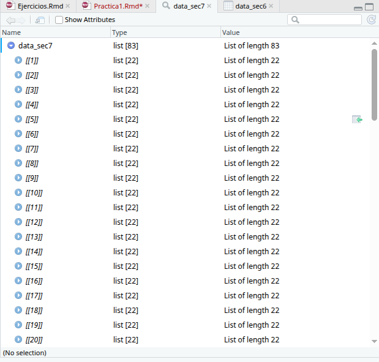

Sin embargo, al activarlo `True`, obtenemos algo mucho más interpretable:

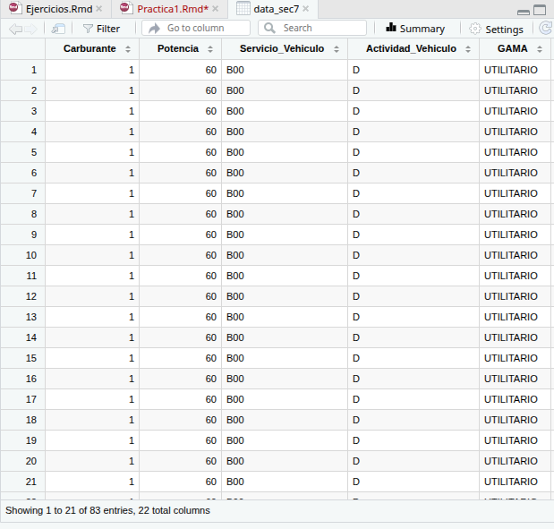

## 7.3 Inspección de los datos

```r
str(data_sec7)
```

[output not shown]

```r
head(data_sec7)
```

|  | Carburante | Potencia | Servicio_Vehiculo | Actividad_Vehiculo | GAMA | Unidades_Matriculadas | Localidad_definitiva | Provincia_definitiva | Codigo_Postal | Viviendas | precio_medio_m2 | Peso_vivienda | RAISON_SOCIAL | RUE_SSOC | Edad_Conductor | Numero de Conductores | Antigüedad | Anos_Antiguedad | Numero_vehiculos_parque | Cluster_GamaPotencia | Cluster_Antiguedad | Cluster_Edad |
| --- | --- | --- | --- | --- | --- | --- | --- | --- | --- | --- | --- | --- | --- | --- | --- | --- | --- | --- | --- | --- | --- | --- |
| 1 | 1 | 60 | B00 | D | UTILITARIO | 0 | ALGECIRAS | CADIZ | 0.0297 | 0.1201 | 0.1799 | 2 | ALGECIREÑA DE MOTOR E INV., S.L. | Ctra. a Malaga, Km. 108 | 18 a 20 años | 0.0132 | 0 | 0 | 0 | cluster_1_GamaPotencia | cluster_1_Antiguedad | cluster_3_Edad |
| 2 | 1 | 60 | B00 | D | UTILITARIO | 0 | ALGECIRAS | CADIZ | 0.0297 | 0.1201 | 0.1799 | 2 | ALGECIREÑA DE MOTOR E INV., S.L. | Ctra. a Malaga, Km. 108 | 21 a 24 años | 0.0569 | 0 | 0 | 0 | cluster_1_GamaPotencia | cluster_1_Antiguedad | cluster_3_Edad |
| 3 | 1 | 60 | B00 | D | UTILITARIO | 0 | ALGECIRAS | CADIZ | 0.0297 | 0.1201 | 0.1799 | 2 | ALGECIREÑA DE MOTOR E INV., S.L. | Ctra. a Malaga, Km. 108 | 25 a 29 años | 0.1086 | 0 | 0 | 0 | cluster_1_GamaPotencia | cluster_1_Antiguedad | cluster_3_Edad |
| 4 | 1 | 60 | B00 | D | UTILITARIO | 0 | ALGECIRAS | CADIZ | 0.0297 | 0.1201 | 0.1799 | 2 | ALGECIREÑA DE MOTOR E INV., S.L. | Ctra. a Malaga, Km. 108 | 30 a 34 años | 0.1392 | 0 | 0 | 0 | cluster_1_GamaPotencia | cluster_1_Antiguedad | cluster_3_Edad |
| 5 | 1 | 60 | B00 | D | UTILITARIO | 0 | ALGECIRAS | CADIZ | 0.0297 | 0.1201 | 0.1799 | 2 | ALGECIREÑA DE MOTOR E INV., S.L. | Ctra. a Malaga, Km. 108 | 35 a 39 años | 0.1706 | 0 | 0 | 0 | cluster_1_GamaPotencia | cluster_1_Antiguedad | cluster_3_Edad |
| 6 | 1 | 60 | B00 | D | UTILITARIO | 0 | ALGECIRAS | CADIZ | 0.0297 | 0.1201 | 0.1799 | 2 | ALGECIREÑA DE MOTOR E INV., S.L. | Ctra. a Malaga, Km. 108 | 40 a 44 años | 0.1577 | 0 | 0 | 0 | cluster_1_GamaPotencia | cluster_1_Antiguedad | cluster_3_Edad |

```r
tail(data_sec7)
```

|  | Carburante | Potencia | Servicio_Vehiculo | Actividad_Vehiculo | GAMA | Unidades_Matriculadas | Localidad_definitiva | Provincia_definitiva | Codigo_Postal | Viviendas | precio_medio_m2 | Peso_vivienda | RAISON_SOCIAL | RUE_SSOC | Edad_Conductor | Numero de Conductores | Antigüedad | Anos_Antiguedad | Numero_vehiculos_parque | Cluster_GamaPotencia | Cluster_Antiguedad | Cluster_Edad |
| --- | --- | --- | --- | --- | --- | --- | --- | --- | --- | --- | --- | --- | --- | --- | --- | --- | --- | --- | --- | --- | --- | --- |
| 78 | 1 | 60 | B00 | D | UTILITARIO | 0 | CHICLANA DE LA FRONTERA | CADIZ | 0.028 | 0.1132 | 0.4255 | 3 | RAMON HOYO, S.L. | AVDA. REYES CATOLICOS, 5 | Más de 74 años | 0.0098 | 0 | 0 | 0 | cluster_1_GamaPotencia | cluster_6_Antiguedad | cluster_3_Edad |
| 79 | 1 | 60 | B00 | D | UTILITARIO | 0 | CHICLANA DE LA FRONTERA | CADIZ | 0.028 | 0.1132 | 0.4255 | 3 | TALLERES COLCHÓN, S.L. | Caraza, 33 | 18 a 20 años | 0.0099 | 0 | 0 | 0 | cluster_1_GamaPotencia | cluster_1_Antiguedad | cluster_3_Edad |
| 80 | 1 | 60 | B00 | D | UTILITARIO | 0 | CHICLANA DE LA FRONTERA | CADIZ | 0.028 | 0.1132 | 0.4255 | 3 | TALLERES COLCHÓN, S.L. | Caraza, 33 | 21 a 24 años | 0.0321 | 0 | 0 | 0 | cluster_1_GamaPotencia | cluster_1_Antiguedad | cluster_3_Edad |
| 81 | 1 | 60 | B00 | D | UTILITARIO | 0 | CHICLANA DE LA FRONTERA | CADIZ | 0.028 | 0.1132 | 0.4255 | 3 | TALLERES COLCHÓN, S.L. | Caraza, 33 | 25 a 29 años | 0.0793 | 0 | 0 | 0 | cluster_1_GamaPotencia | cluster_1_Antiguedad | cluster_3_Edad |
| 82 | 1 | 60 | B00 | D | UTILITARIO | 0 | CHICLANA DE LA FRONTERA | CADIZ | 0.028 | 0.1132 | 0.4255 | 3 | TALLERES COLCHÓN, S.L. | Caraza, 33 | 30 a 34 años | 0.0946 | 0 | 0 | 0 | cluster_1_GamaPotencia | cluster_1_Antiguedad | cluster_3_Edad |
| 83 | 1 | 60 | B00 | D | UTILITARIO | 0 | CHICLANA DE LA FRONTERA | CADIZ | 0.028 | 0.1132 | 0.4255 | 3 | TALLERES COLCHÓN, S.L. | Caraza, 33 | 35 a 39 años | 0.1150 | 0 | 0 | 0 | cluster_1_GamaPotencia | cluster_1_Antiguedad | cluster_3_Edad |

```r
summary(data_sec7)
```

```
   Carburante    Potencia  Servicio_Vehiculo  Actividad_Vehiculo
 Min.   :1    Min.   :60   Length:83          Length:83
 1st Qu.:1    1st Qu.:60   Class :character   Class :character
 Median :1    Median :60   Mode  :character   Mode  :character
 Mean   :1    Mean   :60
 3rd Qu.:1    3rd Qu.:60
 Max.   :1    Max.   :60
     GAMA           Unidades_Matriculadas Localidad_definitiva
 Length:83          Min.   :0             Length:83
 Class :character   1st Qu.:0             Class :character
 Mode  :character   Median :0             Mode  :character
                    Mean   :0
                    3rd Qu.:0
                    Max.   :0
 Provincia_definitiva Codigo_Postal      Viviendas
 Length:83            Min.   :0.0280   Min.   :0.1132
 Class :character     1st Qu.:0.0280   1st Qu.:0.1132
 Mode  :character     Median :0.0280   Median :0.1132
                      Mean   :0.1003   Mean   :0.1487
                      3rd Qu.:0.0297   3rd Qu.:0.1201
                      Max.   :0.4860   Max.   :0.3258
 precio_medio_m2  Peso_vivienda   RAISON_SOCIAL
 Min.   :0.1799   Min.   :2.000   Length:83
 1st Qu.:0.1799   1st Qu.:2.000   Class :character
 Median :0.4255   Median :3.000   Mode  :character
 Mean   :0.3761   Mean   :2.843
 3rd Qu.:0.4255   3rd Qu.:3.000
 Max.   :0.6015   Max.   :4.000
   RUE_SSOC         Edad_Conductor     Numero de Conductores
 Length:83          Length:83          Min.   :0.00740
 Class :character   Class :character   1st Qu.:0.02720
 Mode  :character   Mode  :character   Median :0.06250
                                       Mean   :0.06731
                                       3rd Qu.:0.10035
                                       Max.   :0.17060
   Antigüedad Anos_Antiguedad Numero_vehiculos_parque
 Min.   :0    Min.   :0       Min.   :0
 1st Qu.:0    1st Qu.:0       1st Qu.:0
 Median :0    Median :0       Median :0
 Mean   :0    Mean   :0       Mean   :0
 3rd Qu.:0    3rd Qu.:0       3rd Qu.:0
 Max.   :0    Max.   :0       Max.   :0
 Cluster_GamaPotencia Cluster_Antiguedad Cluster_Edad
 Length:83            Length:83          Length:83
 Class :character     Class :character   Class :character
 Mode  :character     Mode  :character   Mode  :character
```

# 8 8. Fichero JSON *iris_json.json*

## 8.1 Importar el fichero `iris_json.json`

1. Abrir el fichero iris_json.json con un editor de texto (el de RStudio vale) para ver qué contiene. Comprobaremos que se puede leer e interepretar con facilidad.

[figure not shown]

2. Importar el fichero a R con read_json.

```r
filename <- ("./data/iris_json.json")
data_sec8 <- read_json(filename)
```

```r
filename <- ("./data/results/iris.Rdata")
save(data_sec8_2, file=filename)
```

## 8.2 Inspección de los datos

```r
str(data_sec8_2)
```

```
'data.frame':   150 obs. of  5 variables:
 $ Sepal.Length: num  5.1 4.9 4.7 4.6 5 5.4 4.6 5 4.4 4.9 ...
 $ Sepal.Width : num  3.5 3 3.2 3.1 3.6 3.9 3.4 3.4 2.9 3.1 ...
 $ Petal.Length: num  1.4 1.4 1.3 1.5 1.4 1.7 1.4 1.5 1.4 1.5 ...
 $ Petal.Width : num  0.2 0.2 0.2 0.2 0.2 0.4 0.3 0.2 0.2 0.1 ...
 $ Species     : chr  "setosa" "setosa" "setosa" "setosa" ...
```

```r
head(data_sec8_2)
```

|  | Sepal.Length | Sepal.Width | Petal.Length | Petal.Width | Species |
| --- | --- | --- | --- | --- | --- |
| 1 | 5.1 | 3.5 | 1.4 | 0.2 | setosa |
| 2 | 4.9 | 3.0 | 1.4 | 0.2 | setosa |
| 3 | 4.7 | 3.2 | 1.3 | 0.2 | setosa |
| 4 | 4.6 | 3.1 | 1.5 | 0.2 | setosa |
| 5 | 5.0 | 3.6 | 1.4 | 0.2 | setosa |
| 6 | 5.4 | 3.9 | 1.7 | 0.4 | setosa |

```r
tail(data_sec8_2)
```

|  | Sepal.Length | Sepal.Width | Petal.Length | Petal.Width | Species |
| --- | --- | --- | --- | --- | --- |
| 145 | 6.7 | 3.3 | 5.7 | 2.5 | virginica |
| 146 | 6.7 | 3.0 | 5.2 | 2.3 | virginica |
| 147 | 6.3 | 2.5 | 5.0 | 1.9 | virginica |
| 148 | 6.5 | 3.0 | 5.2 | 2.0 | virginica |
| 149 | 6.2 | 3.4 | 5.4 | 2.3 | virginica |
| 150 | 5.9 | 3.0 | 5.1 | 1.8 | virginica |

```r
summary(data_sec8_2)
```

```
  Sepal.Length    Sepal.Width     Petal.Length    Petal.Width
 Min.   :4.300   Min.   :2.000   Min.   :1.000   Min.   :0.100
 1st Qu.:5.100   1st Qu.:2.800   1st Qu.:1.600   1st Qu.:0.300
 Median :5.800   Median :3.000   Median :4.350   Median :1.300
 Mean   :5.843   Mean   :3.057   Mean   :3.758   Mean   :1.199
 3rd Qu.:6.400   3rd Qu.:3.300   3rd Qu.:5.100   3rd Qu.:1.800
 Max.   :7.900   Max.   :4.400   Max.   :6.900   Max.   :2.500
   Species
 Length:150
 Class :character
 Mode  :character
```

## 8.3 Exportar datos en formato JSON

1. Lee los datos iris almacendos previamente en iris.Rdata y guardalos en json usando write_json. Abrir el fichero con RStudio y comprobar el resultado.

```r
filename <- "./data/results/iris.Rdata"
load(filename)
write_json(data_sec8_2, './data/results/iris.json')
```

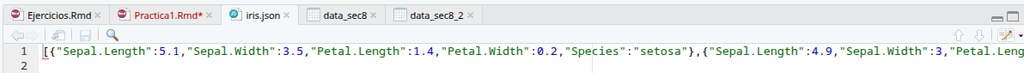

2. Como alternativa, obtener la representación JSON de los datos con toJSON y luego almacenarlos con write_file. Observar la diferencia de usar o no el parámetro pretty en toJSON.

```r
data_sec8_3 <- toJSON(data_sec8_2)
filename <- 'data/results/iris_json_v2.json'
write_file(data_sec8_3, filename)
```

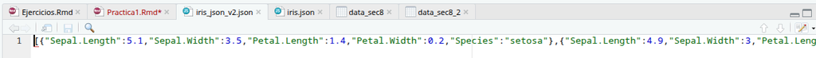

Exactamente el mismo resultado! (RStudio muestra todo como si estuviera en la misma línea, pero mi lector KWrite lo muestra mejor) e.g.

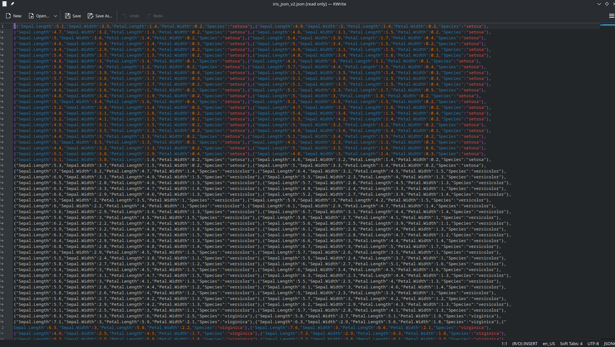

# 9 9. Fichero ERCA.xlsx